# Reproducible Research: Peer Assessment 1

sirir

Saturday, November 15, 2014

#### Loading and preprocessing the data

Loading data

```r
data <- read.csv("./activity.csv",sep = ",",header = TRUE, na.strings ="NA",
                   colClasses = c('integer','Date','factor'))
```

Summary of Original data

```r
summary(data)
```

```
##      steps             date               interval
##  Min.   :  0.00   Min.   :2012-10-01   0      :   61
##  1st Qu.:  0.00   1st Qu.:2012-10-16   10     :   61
##  Median :  0.00   Median :2012-10-31   100    :   61
##  Mean   : 37.38   Mean   :2012-10-31   1000   :   61
##  3rd Qu.: 12.00   3rd Qu.:2012-11-15   1005   :   61
##  Max.   :806.00   Max.   :2012-11-30   1010   :   61
##  NA's   :2304                          (Other):17202
```

```r
head(data)
```

```
##   steps       date interval
## 1    NA 2012-10-01        0
## 2    NA 2012-10-01        5
## 3    NA 2012-10-01       10
## 4    NA 2012-10-01       15
## 5    NA 2012-10-01       20
## 6    NA 2012-10-01       25
```

Removing missing values from the original data and assigning it to ‘processedData’ variable

```r
processedData <- na.omit(data)
```

```r
head(processedData)
```

```
##     steps       date interval
## 289     0 2012-10-02        0
## 290     0 2012-10-02        5
## 291     0 2012-10-02       10
## 292     0 2012-10-02       15
## 293     0 2012-10-02       20
## 294     0 2012-10-02       25
```

Summary of processed Data

```r
summary(processedData)
```

```
##      steps             date               interval
##  Min.   :  0.00   Min.   :2012-10-02   0      :   53
##  1st Qu.:  0.00   1st Qu.:2012-10-16   10     :   53
##  Median :  0.00   Median :2012-10-29   100    :   53
##  Mean   : 37.38   Mean   :2012-10-30   1000   :   53
##  3rd Qu.: 12.00   3rd Qu.:2012-11-16   1005   :   53
##  Max.   :806.00   Max.   :2012-11-29   1010   :   53
##                                        (Other):14946
```

```r
steps.per.day <- tapply(processedData$steps, processedData$date, FUN = sum)
head(steps.per.day)
```

```
## 2012-10-02 2012-10-03 2012-10-04 2012-10-05 2012-10-06 2012-10-07
##        126      11352      12116      13294      15420      11015
```

Histogram of total number of steps per day.

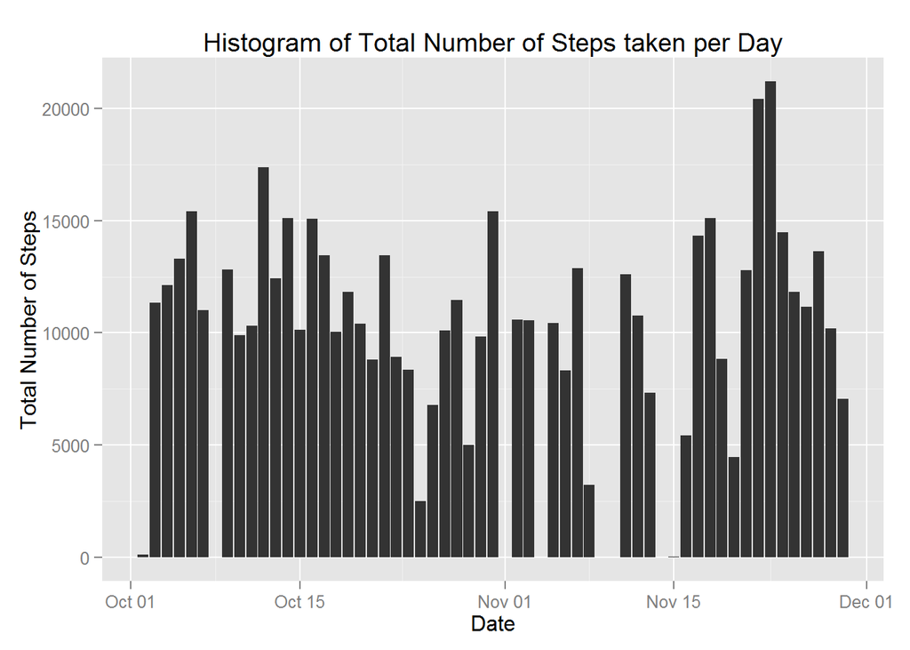

```r
plot1 <- ggplot(processedData, aes(date, steps)) + geom_bar(stat = "identity",
        binwidth = .5) + labs(title = "Histogram of Total Number of Steps taken per Day", x = "Date", y = "Total Number of Steps")
print(plot1)
```

Mean total number of steps taken per day

```r
mean(total.steps)
```

```
## [1] 10766.19
```

Median total number of steps taken per day

```r
median(total.steps)
```

```
## [1] 10765
```

Average daily activity pattern

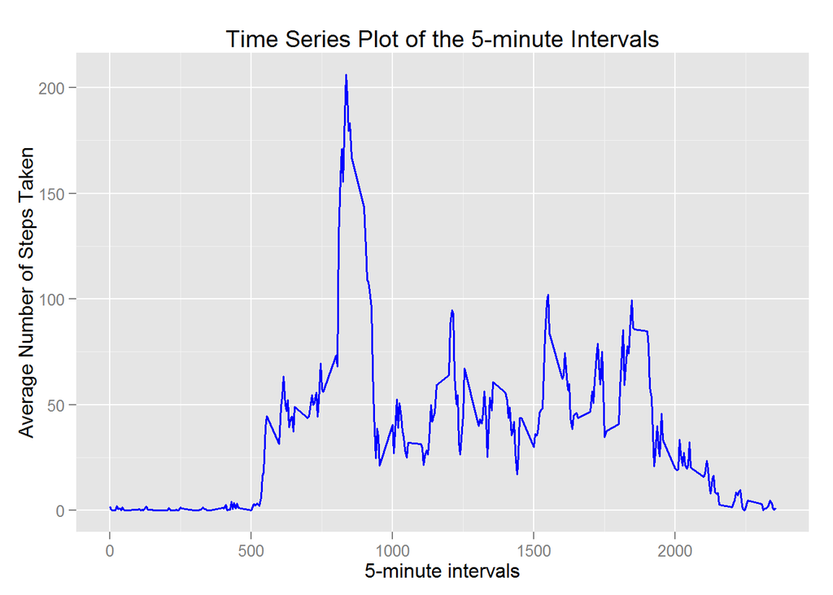

```r
averages <- aggregate(processedData$steps, list(interval = as.numeric(as.character(processedData$interval))), FUN = "mean")
names(averages)[2] <- "Avg.Steps"

plot2 <- ggplot(averages, aes(interval, Avg.Steps)) + geom_line(color = "blue", size = 0.7) + labs(title = "Time Series Plot of the 5-minute Intervals", x = "5-minute intervals", y = "Average Number of Steps Taken")
print(plot2)
```

The 5-minute inteval with maximum steps across all the day

```r
averages[averages$Avg.Steps == max(averages$Avg.Steps),]
```

```
##     interval Avg.Steps
## 104      835  206.1698
```

#### Imputing missing values

The total number of missing values in the dataset

```r
sum(!complete.cases(data))
```

```
## [1] 2304
```

Imputing missing values by using mean for that 5-minute interval

```r
impData <- data
for (i in 1:nrow(impData)) {
    if (is.na(impData$steps[i])) {
        impData$steps[i] <- averages[which(impData$interval[i] == averages$interval), ]$Avg.Steps
    }
}
```

Number of missing values after after imputation

```r
sum(!complete.cases(impData))
```

```
## [1] 0
```

New dataset that is equal to the original dataset but with the missing data

Summary of New dataset

```r
summary(impData)
```

```
##      steps             date               interval
##  Min.   :  0.00   Min.   :2012-10-01   0      :   61
##  1st Qu.:  0.00   1st Qu.:2012-10-16   10     :   61
##  Median :  0.00   Median :2012-10-31   100    :   61
##  Mean   : 37.38   Mean   :2012-10-31   1000   :   61
##  3rd Qu.: 27.00   3rd Qu.:2012-11-15   1005   :   61
##  Max.   :806.00   Max.   :2012-11-30   1010   :   61
##                                        (Other):17202
```

Summary of Original dataset

```r
summary(data)
```

```
##      steps             date               interval
##  Min.   :  0.00   Min.   :2012-10-01   0      :   61
##  1st Qu.:  0.00   1st Qu.:2012-10-16   10     :   61
##  Median :  0.00   Median :2012-10-31   100    :   61
##  Mean   : 37.38   Mean   :2012-10-31   1000   :   61
##  3rd Qu.: 12.00   3rd Qu.:2012-11-15   1005   :   61
##  Max.   :806.00   Max.   :2012-11-30   1010   :   61
##  NA's   :2304                          (Other):17202
```

Histogram of the total number of steps taken each day after imputing the missing vales

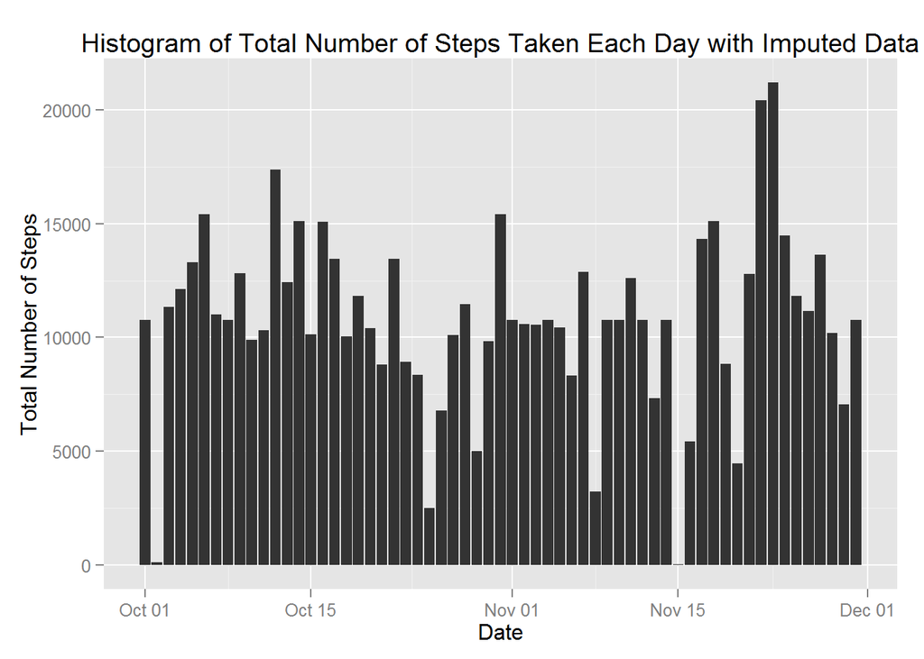

```r
plot3 <- ggplot(impData, aes(date, steps)) + geom_bar(stat = "identity",binwidth = .5) +
        labs(title = "Histogram of Total Number of Steps Taken Each Day with Imputed Data",x = "Date", y = "Total Number of Steps")
print(plot3)
```

Calculated Mean total number of steps taken per day with Imputed dataset

```r
total.steps.impute <- tapply(impData$steps, impData$date, FUN = sum)
mean(total.steps.impute)
```

```
## [1] 10766.19
```

Calculated Median total number of steps taken per day with Imputed dataset.

```r
median(total.steps.impute)
```

```
## [1] 10766.19
```

Observartions

The mean total number of steps taken per day remained same before and after the imputation

The new Median is slightly higher than the old medain